# Monte Carlo Study of the MSE Decomposition in k-NN Regression

Jiachen Chen, Yiwen Zhao, Yuxi Ren, Jintong Li

## Overview

This vignette demonstrates a minimal Monte Carlo framework to study the **mean squared error (MSE)** decomposition for **k-nearest neighbors (k-NN) regression**.

We work under a known data generating process (DGP):

$$Y = f(X) + \varepsilon, \qquad X \sim \mathrm{Unif}(0,1)^d,\quad
\varepsilon \sim \mathcal{N}(0,\sigma^2).$$

The goal is to estimate (pointwise on a grid) the components:

- **Bias**: $\mathrm{Bias}(x) = E[\hat f(x)] - f(x)$
- **Variance**: $\mathrm{Var}(\hat f(x))$
- **MSE for estimating the signal**: $\mathrm{MSE}_f(x) = \mathrm{Bias}(x)^2 + \mathrm{Var}(\hat f(x))$
- **MSE for predicting outcomes**: $\mathrm{MSE}_Y(x) = \mathrm{MSE}_f(x) + \sigma^2$

## DGP and target functions

We support two target functions:

1. **Baseline (1D)**: $f(x) = \sin(2\pi x)$
2. **Dimensionality extension (2D)**: $f(x_1, x_2) = \sin(\sqrt{x_1^2 + x_2^2})$

```r
x <- dgp_x(n = 10, d = 1, seed = 1)
y <- dgp_y(x, sigma = 0.2, type = "1d", seed = 2)
head(cbind(x, y))
```

```
##                         y
## [1,] 0.2655087  0.8158732
## [2,] 0.3721239  0.7567386
## [3,] 0.5728534 -0.1243629
## [4,] 0.9082078 -0.7713756
## [5,] 0.2016819  0.9382187
## [6,] 0.8983897 -0.5694565
```

## Monte Carlo bias–variance decomposition (1D)

Below is a small Monte Carlo run (smaller B for vignette speed; the project default is typically B=500).

```r
res_1d <- mc_knn_decomp(
  n = 200, k = 15, B = 200,
  sigma = 0.2, d = 1, type = "1d",
  grid_size = 101, seed = 123
)

str(res_1d$settings)
```

```
## List of 8
##  $ n        : num 200
##  $ k        : num 15
##  $ B        : num 200
##  $ sigma    : num 0.2
##  $ d        : num 1
##  $ type     : chr "1d"
##  $ grid_size: num 101
##  $ seed     : num 123
```

```r
head(res_1d$pointwise)
```

```
##     x1 x2     f_true f_hat_mean        bias        bias2    variance
## 1 0.00 NA 0.00000000  0.2471863 0.247186319 6.110108e-02 0.006797334
## 2 0.01 NA 0.06279052  0.2471863 0.184395800 3.400181e-02 0.006797334
## 3 0.02 NA 0.12533323  0.2473344 0.122001149 1.488428e-02 0.006757730
## 4 0.03 NA 0.18738131  0.2502111 0.062829777 3.947581e-03 0.006305599
## 5 0.04 NA 0.24868989  0.2687940 0.020104125 4.041759e-04 0.005306465
## 6 0.05 NA 0.30901699  0.3140325 0.005015503 2.515527e-05 0.004782916
##         mse_f      mse_y
## 1 0.067898411 0.10789841
## 2 0.040799145 0.08079915
## 3 0.021642010 0.06164201
## 4 0.010253180 0.05025318
## 5 0.005710641 0.04571064
## 6 0.004808072 0.04480807
```

## Assumption Check

In our simulation, the predictor variable $X$ is generated independently, and the noise term $\epsilon$ is also generated independently with mean zero and constant variance. This ensures that the observations satisfy the independence and constant variance assumptions required for bias–variance decomposition.

The true regression function is smooth, which makes k-NN regression appropriate for estimating the conditional mean function. Therefore, the assumptions underlying our simulation and analysis are satisfied.

### Visualizing the decomposition

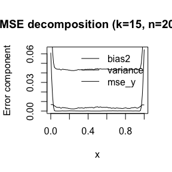

```r
plot_mse_1d(res_1d, show = c("bias2", "variance", "mse_y"))
```

### Comparing f(x) (mean prediction) to the true f(x)

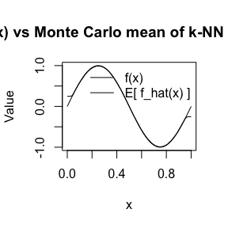

```r
pw <- res_1d$pointwise
plot(pw$x1, pw$f_true, type = "l", xlab = "x", ylab = "Value",
     main = "True f(x) vs Monte Carlo mean of k-NN predictions")
lines(pw$x1, pw$f_hat_mean)
legend("topright", legend = c("f(x)", "E[ f_hat(x) ]"), lty = 1, bty = "n")
```

## Scanning k to find an empirical optimal k

We can scan over candidate k values and compute the grid-averaged MSE.

```r
k_values <- c(1, 3, 5, 10, 15, 25, 40)
curve <- mc_knn_curve(
  k_values = k_values,
  n = 200, B = 200, sigma = 0.2,
  d = 1, type = "1d",
  grid_size = 101, seed = 10,
  target = "y"
)
curve
```

```
##    k    avg_mse
## 1  1 0.08051377
## 2  3 0.05353284
## 3  5 0.04845803
## 4 10 0.04559029
## 5 15 0.04607908
## 6 25 0.05102193
## 7 40 0.06690294
```

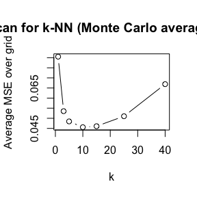

```r
plot(curve$k, curve$avg_mse, type = "b",
     xlab = "k", ylab = "Average MSE over grid",
     main = "k-scan for k-NN (Monte Carlo average MSE)")
```

In the repository, tests are written in a separate file using **testthat**.  
To run the tests locally:

```r
# In the project root:
# install.packages("testthat")
# testthat::test_file("test.R")
```

(For the Basic Implementation Check submission, include the `test.R` file in the repo.)

## References (BibTeX)

[output not shown]

> **Note:** The figures produced in this R Markdown document are preliminary drafts for illustrating patterns and verifying results. They do not represent the final figures。

Cover, T., and P. Hart. 1967. “Nearest Neighbor Pattern Classification.” *IEEE Transactions on Information Theory* 13 (1): 21–27. https://doi.org/10.1109/TIT.1967.1053964.

Gareth James, Daniela Witten, Trevor Hastie, and Robert Tibshirani. 2013. *An Introduction to Statistical Learning*. Vol. 103. Springer Texts in Statistics. New York, NY: Springer New York. https://doi.org/10.1007/978-1-4614-7138-7.

Hastie, Trevor, Robert Tibshirani, and Jerome Friedman. 2009. *The Elements of Statistical Learning*. Springer Series in Statistics. New York, NY: Springer New York. https://doi.org/10.1007/978-0-387-84858-7.

Robert, Christian P., and George Casella. 2004. *Monte Carlo Statistical Methods*. Springer Texts in Statistics. New York, NY: Springer New York. https://doi.org/10.1007/978-1-4757-4145-2.

Wickham, Hadley, and Jennifer Bryan. 2023. “R Packages.” https://r-pkgs.org/.